# LAB0_sec02.Rmd

The following R code loads packages needed in this assignment.

```r
library(readr)
library(dplyr)
```

```r
library(ggplot2)
```

## LAB for Class04

**The Goal** Given a data set containing characteristics about the Boston housing market, explore methods for predicting housing prices.

You’ll need to clone this repository using RStudio first. Practice writing and adding code that produces a simple linear regression, multiple linear regression, and polynomial regression. Include a visual and quantitative method for assessing whether some models may better explain housing prices than other models.

We will discuss some models students have proposed and ways to communicate these models to a lay audience.

### Data

The dataset and the data dictionary are included in the folder called data.

### Questions

SIMPLE LINEAR REGRESSION MODEL - DISTANCE TO EMPLOYMENT CENTERS

```r
boston_data <- read.csv("boston_data.csv")
LRModel <- lm(MEDV~DIS,data=boston_data)
summary(LRModel)
```

```
##
## Call:
## lm(formula = MEDV ~ DIS, data = boston_data)
##
## Residuals:
##     Min      1Q  Median      3Q     Max
## -15.016  -5.556  -1.865   2.288  30.377
##
## Coefficients:
##             Estimate Std. Error t value Pr(>|t|)
## (Intercept)  18.3901     0.8174  22.499  < 2e-16 ***
## DIS           1.0916     0.1884   5.795 1.21e-08 ***
## ---
## Signif. codes:  0 '***' 0.001 '**' 0.01 '*' 0.05 '.' 0.1 ' ' 1
##
## Residual standard error: 8.914 on 504 degrees of freedom
## Multiple R-squared:  0.06246,    Adjusted R-squared:  0.0606
## F-statistic: 33.58 on 1 and 504 DF,  p-value: 1.207e-08
```

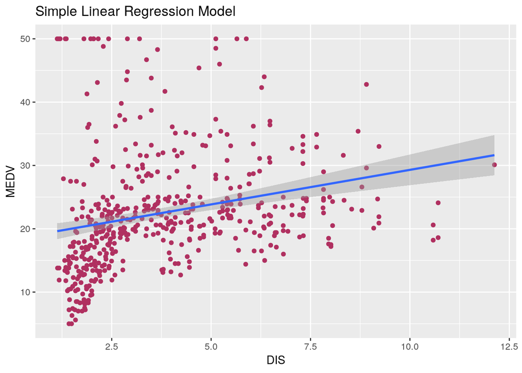

```r
ggplot(boston_data, aes(x=DIS, y=MEDV)) + geom_point(color = 'maroon') + geom_smooth(method=lm) + ggtitle('Simple Linear Regression Model')
```

MULTIPLE LINEAR REGRESSION MODEL - DISTANCE, RADIUS, TAX, CRIME

```r
boston_data <- read.csv("boston_data.csv")
MRModel <- lm(MEDV~DIS + RAD + CRIM + TAX, data=boston_data)
summary(MRModel)
```

```
##
## Call:
## lm(formula = MEDV ~ DIS + RAD + CRIM + TAX, data = boston_data)
##
## Residuals:
##     Min      1Q  Median      3Q     Max
## -13.253  -4.820  -1.996   2.971  32.517
##
## Coefficients:
##              Estimate Std. Error t value Pr(>|t|)
## (Intercept) 35.345158   1.832729  19.286  < 2e-16 ***
## DIS         -0.080494   0.199078  -0.404    0.686
## RAD          0.411452   0.101929   4.037 6.27e-05 ***
## CRIM        -0.248605   0.052826  -4.706 3.27e-06 ***
## TAX         -0.038060   0.005197  -7.324 9.68e-13 ***
## ---
## Signif. codes:  0 '***' 0.001 '**' 0.01 '*' 0.05 '.' 0.1 ' ' 1
##
## Residual standard error: 7.923 on 501 degrees of freedom
## Multiple R-squared:  0.2638, Adjusted R-squared:  0.2579
## F-statistic: 44.88 on 4 and 501 DF,  p-value: < 2.2e-16
```

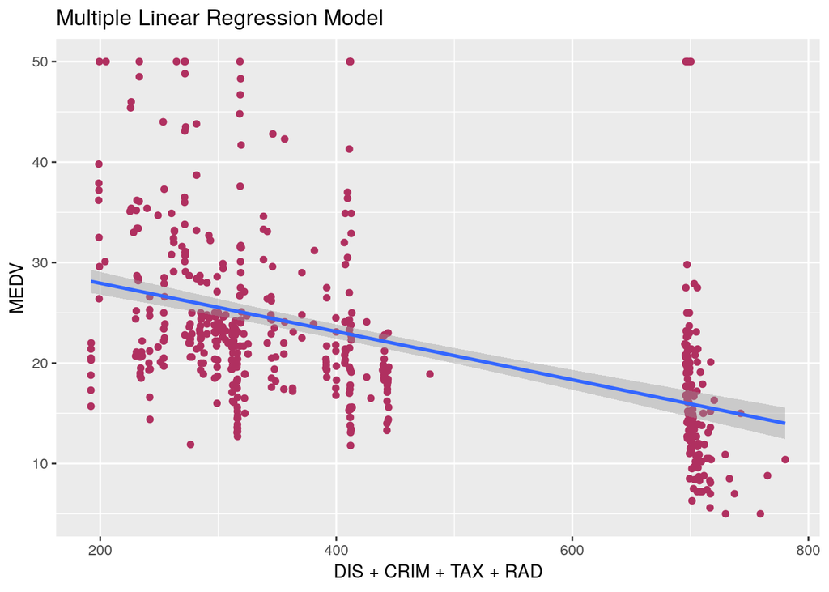

```r
ggplot(boston_data, aes(x=DIS + CRIM + TAX + RAD, y=MEDV)) + geom_point(color = 'maroon') + geom_smooth(method=lm) + ggtitle('Multiple Linear Regression Model')
```

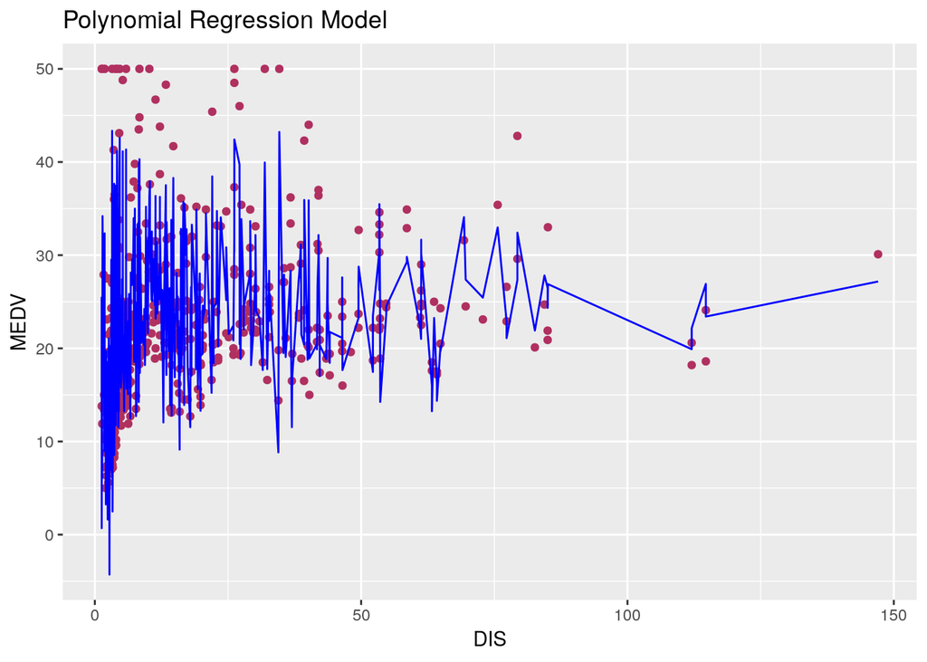

```r
Boston_data_1 = boston_data
Boston_data_1$DIS=Boston_data_1$DIS^2
Boston_data_1$DIS3=Boston_data_1$DIS^3
Boston_data_1$DIS4=Boston_data_1$DIS^4
PRModel=lm(MEDV ~ ., data=Boston_data_1)
ggplot() + geom_point(aes(x = Boston_data_1$DIS, y = Boston_data_1$MEDV), color = 'maroon') + geom_line(aes(x=Boston_data_1$DIS,y=predict(PRModel,newdata=Boston_data_1)),color='blue') + ggtitle('Polynomial Regression Model') + xlab('DIS') + ylab('MEDV')
```

- How would you explain SSE?

The error is the difference between the value that has been actually observed in the data and the value that our model predcits. However, the sum of the errors is zero, on average, since errors can be equally likely positive or negative. This would mean that there are no errors, which is not true. By squaring the errors, this problem is overcome. The smaller the SSE, the more accurate a model is.

- How would you explain your model?